# Mendelian Randomization Analysis: Alcohol Consumption and Alzheimer's Disease

By Dr. Shea Andrews, generated on 2018-09-02

```
## [1] FALSE
```

## Data sources

*Alcohol Consumption* (Clarke et al 2017): SNPs associated with alcohol consumption were selected from a GWAS of alcohol consumption (drinks per week adjusted for sex, age and weight) performed in 112,117 individuals from the UK Biobank [29]. Participants were of European ancestry, mean age was 59.6 and 52.7% of the cohort was female.

*Late Onset Alzheimer’s disease* (LOAD, Lambert et al 2013): The International Genomics of Alzheimer’s Project (IGAP) is a meta-analysis of 4 previously published GWAS datasets: the European Alzheimer’s Disease Imitative (EADI), the Alzheimer Disease Genetics Consortium (ADGC), Cohorts for Heart and Aging Research in Genomic Epidemiology (CHARGE), and Genetic and Environmental Risk in AD (GERAD) and includes a sample of 17,008 LOAD cases and 37,154 cognitively normal elder controls. Participants in IGAP were of European ancestry, the average age was 71 and 58.4% of participants were women.

*Alzheimer’s Age of Onset Surivial* (AAOS, Huang et al 2017): A GWAS of age of onset in LOAD was conducted in 14,406 AD case samples and 25,849 control samples from the IGAP using Cox proportional hazard regressions. Participants were of European ancestry, in cases the the average AAO was 74.8 and 61.7% were women, in controls the average AAE was 79.0 and 59.6% were women.

*CSF Ab42, tau & ptau* (AB42, ptau, tau, Deming et al 2017): A GWAS of CSF AB42, ptau and tau levels (pg/mL) was conducted in 3,146 participants. Participants were of Eurpean ancestry.

## Instrumental Variables

**LD Clumping:** For standard two sample MR it is important to ensure that the instruments for the exposure are independent. LD clumping can be performed using the data_clump function from the TwoSampleMR package, which uses EUR samples from the 1000 genomes project to estimate LD between SNPs and amonst SNPs that have and LD above a given threshold, only the SNP with the lowest p-value will be retained.

**Proxy SNPs:** SNPs associated with Alcohol Consumption were extracted from the GWAS of LOAD, AAOS, AB42, ptau and tau. Where SNPs were not available in the outcome GWAS, the EUR thousand genomes was queried to identified potential proxy SNPs that are in linkage disequilibrium (r2 > 0.8) of the missing SNP.

### Alcohol Consumption

Alcohol Consumption: 414 SNPs (Table 1) were assoicated with were associated with Alcohol Consumption at p < 5e-8. After LD clumping, 403 of 414 SNPs were removed.

**Table 1:** Independent SNPS associated with Alcohol Consumption

| SNP | CHR | POS | Effect_allele | Non_Effect_allele | EAF | Beta | SE | P | r2 | N |
| --- | --- | --- | --- | --- | --- | --- | --- | --- | --- | --- |
| rs1260326 | 2 | 27730940 | T | C | 0.393400 | -0.02839 | 0.002973 | 1.341e-21 | 3.846782e-04 | 112176 |
| rs13006480 | 2 | 27987221 | G | C | 0.164000 | -0.01721 | 0.003017 | 1.170e-08 | 8.121605e-05 | 108886 |
| rs13078384 | 3 | 85264266 | A | G | 0.311600 | 0.01853 | 0.002982 | 5.171e-10 | 1.473056e-04 | 111539 |
| rs9841829 | 3 | 85569361 | G | T | 0.226900 | 0.01869 | 0.002976 | 3.359e-10 | 1.225515e-04 | 111977 |
| rs11940694 | 4 | 39414993 | A | G | 0.393700 | -0.02694 | 0.003042 | 8.430e-19 | 3.464800e-04 | 107311 |
| rs193099203 | 4 | 99630017 | T | C | 0.007120 | -0.03105 | 0.002996 | 3.787e-25 | 1.363107e-05 | 110458 |
| rs62325470 | 4 | 99644166 | T | C | 0.007253 | -0.01783 | 0.002980 | 2.170e-09 | 4.578139e-06 | 111745 |
| rs146788033 | 4 | 99941138 | G | A | 0.013410 | -0.02845 | 0.002993 | 2.053e-21 | 2.141707e-05 | 110683 |
| rs145452708 | 4 | 100248642 | C | G | 0.009985 | -0.03427 | 0.002976 | 1.148e-30 | 2.321924e-05 | 112071 |
| rs2298755 | 4 | 100261038 | G | C | 0.413000 | 0.01793 | 0.003004 | 2.399e-09 | 1.558758e-04 | 110134 |

[output cut: 1 more lines]

### LOAD

**Table 2:** SNPS associated with Alcohol Consumption avalible in LOAD GWAS

| SNP | CHR | POS | Effect_allele | Non_Effect_allele | EAF | Beta | SE | P | r2 | N |
| --- | --- | --- | --- | --- | --- | --- | --- | --- | --- | --- |
| rs1260326 | 2 | 27730940 | T | C | 0.4232 | -0.0008 | 0.0161 | 0.96080 | 3.124503e-07 | 54162 |
| rs13006480 | 2 | 27987221 | G | C | 0.8170 | -0.0014 | 0.0249 | 0.95640 | 5.860831e-07 | 54162 |
| rs13078384 | 3 | 85264266 | A | G | 0.3238 | -0.0098 | 0.0182 | 0.58970 | 4.205660e-05 | 54162 |
| rs9841829 | 3 | 85569361 | G | T | 0.7642 | -0.0191 | 0.0185 | 0.30320 | 1.314763e-04 | 54162 |
| rs11940694 | 4 | 39414993 | A | G | 0.4189 | -0.0363 | 0.0167 | 0.02941 | 6.415116e-04 | 54162 |
| rs62325470 | 4 | 99644166 | T | C | 0.0149 | 0.1208 | 0.0723 | 0.09467 | 4.283812e-04 | 54162 |
| rs145452708 | 4 | 100248642 | C | G | 0.0228 | 0.0107 | 0.0580 | 0.85340 | 5.101711e-06 | 54162 |
| rs2298755 | 4 | 100263834 | G | C | 0.3863 | 0.0089 | 0.0159 | 0.57860 | 3.755700e-05 | 54162 |
| rs74764239 | 4 | 100618891 | T | A | 0.9676 | -0.0003 | 0.0428 | 0.99530 | 5.643043e-09 | 54162 |

### AAOS

Of the the 11 SNPs associated with Alcohol Consumption, 11 were available in the AAOS GWAS (Table 3).

**Table 3:** SNPS associated with available in AAOS GWAS

| SNP | CHR | POS | Effect_allele | Non_Effect_allele | EAF | Beta | SE | P | r2 | N |
| --- | --- | --- | --- | --- | --- | --- | --- | --- | --- | --- |
| rs1260326 | 2 | 27730940 | T | C | 0.4232 | -0.0007 | 0.0123 | 0.9537 | 2.392197e-07 | 40255 |
| rs13006480 | 2 | 27987221 | C | G | 0.8170 | -0.0144 | 0.0250 | 0.5638 | 6.200520e-05 | 40255 |
| rs13078384 | 3 | 85264266 | A | G | 0.3238 | -0.0137 | 0.0131 | 0.2964 | 8.219079e-05 | 40255 |
| rs9841829 | 3 | 85569361 | T | G | 0.7642 | 0.0049 | 0.0143 | 0.7331 | 8.653125e-06 | 40255 |
| rs11940694 | 4 | 39414993 | A | G | 0.4189 | -0.0149 | 0.0139 | 0.2837 | 1.080846e-04 | 40255 |
| rs193099203 | 4 | 99630017 | T | C | 0.0227 | 0.1129 | 0.1139 | 0.3214 | 5.655508e-04 | 40255 |
| rs62325470 | 4 | 99644166 | T | C | 0.0149 | 0.1635 | 0.1218 | 0.1795 | 7.847514e-04 | 40255 |
| rs146788033 | 4 | 99941138 | A | G | 0.9682 | -0.1120 | 0.0875 | 0.2007 | 7.724284e-04 | 40255 |
| rs145452708 | 4 | 100248642 | C | G | 0.0228 | 0.1068 | 0.0870 | 0.2198 | 5.082657e-04 | 40255 |
| rs2298755 | 4 | 100261038 | C | G | 0.6070 | -0.0163 | 0.0194 | 0.4004 | 1.267612e-04 | 40255 |

[output cut: 1 more lines]

### AB42

**Table 4:** SNPS associated with Alcohol Consumption avalible in ab42 GWAS

| SNP | CHR | POS | Effect_allele | Non_Effect_allele | EAF | Beta | SE | P | r2 | N |
| --- | --- | --- | --- | --- | --- | --- | --- | --- | --- | --- |
| rs1260326 | 2 | 27730940 | T | C | 0.4048200 | 0.002212 | 0.004110 | 0.590400 | 2.357819e-06 | 3115 |
| rs13006480 | 2 | 27987221 | G | C | 0.1986450 | -0.003989 | 0.005237 | 0.446400 | 5.065947e-06 | 2999 |
| rs13078384 | 3 | 85264266 | A | G | 0.3015860 | -0.003516 | 0.004403 | 0.424600 | 5.207771e-06 | 3070 |
| rs9841829 | 3 | 85569361 | G | T | 0.2228980 | 0.005628 | 0.004810 | 0.242100 | 1.097292e-05 | 3108 |
| rs11940694 | 4 | 39423789 | G | A | 0.3763780 | 0.003275 | 0.004145 | 0.429500 | 5.034986e-06 | 3093 |
| rs146788033 | 4 | 99941138 | G | A | 0.0224515 | 0.004287 | 0.012800 | 0.737800 | 8.067159e-07 | 2618 |
| rs145452708 | 4 | 100248642 | C | G | 0.0178472 | 0.028050 | 0.013330 | 0.035380 | 2.758321e-05 | 3109 |
| rs2298755 | 4 | 100261038 | G | C | 0.3977980 | -0.005725 | 0.004142 | 0.167000 | 1.570311e-05 | 3108 |
| rs74764239 | 4 | 100618891 | T | A | 0.0257622 | 0.031160 | 0.011420 | 0.006408 | 4.873857e-05 | 3113 |

### Ptau

Of the the 11 SNPs associated with Alcohol Consumption, 9 were available in the CSF Ptau GWAS (Table 5).

**Table 5:** SNPS associated with Alcohol Consumption avalible in Ptau GWAS

| SNP | CHR | POS | Effect_allele | Non_Effect_allele | EAF | Beta | SE | P | r2 | N |
| --- | --- | --- | --- | --- | --- | --- | --- | --- | --- | --- |
| rs1260326 | 2 | 27730940 | T | C | 0.4048200 | -0.0051210 | 0.005377 | 0.34100 | 1.263717e-05 | 2833 |
| rs13006480 | 2 | 27987221 | G | C | 0.1986450 | -0.0003821 | 0.006823 | 0.95530 | 4.648220e-08 | 2734 |
| rs13078384 | 3 | 85264266 | A | G | 0.3015860 | 0.0117300 | 0.005766 | 0.04203 | 5.796290e-05 | 2794 |
| rs9841829 | 3 | 85569361 | G | T | 0.2228980 | 0.0052410 | 0.006310 | 0.40630 | 9.515739e-06 | 2826 |
| rs11940694 | 4 | 39414993 | A | G | 0.4051590 | -0.0060930 | 0.005791 | 0.29280 | 1.789447e-05 | 2197 |
| rs146788033 | 4 | 99941138 | G | A | 0.0224515 | 0.0146800 | 0.017780 | 0.40900 | 9.459448e-06 | 2347 |
| rs145452708 | 4 | 100248642 | C | G | 0.0178472 | 0.0067390 | 0.017130 | 0.69410 | 1.592099e-06 | 2827 |
| rs2298755 | 4 | 100261038 | G | C | 0.3977980 | 0.0042170 | 0.005459 | 0.43980 | 8.520047e-06 | 2829 |
| rs74764239 | 4 | 100618891 | T | A | 0.0257622 | 0.0108600 | 0.014540 | 0.45510 | 5.920216e-06 | 2831 |

### Tau

**Table 6:** SNPS associated with Alcohol Consumption avalible in tau GWAS

| SNP | CHR | POS | Effect_allele | Non_Effect_allele | EAF | Beta | SE | P | r2 | N |
| --- | --- | --- | --- | --- | --- | --- | --- | --- | --- | --- |
| rs1260326 | 2 | 27730940 | T | C | 0.4048200 | -0.0020610 | 0.005737 | 0.7194 | 2.046898e-06 | 3108 |
| rs13006480 | 2 | 27987221 | G | C | 0.1986450 | -0.0007751 | 0.007325 | 0.9157 | 1.912705e-07 | 2991 |
| rs13078384 | 3 | 85264266 | A | G | 0.3015860 | 0.0055420 | 0.006124 | 0.3655 | 1.293860e-05 | 3062 |
| rs9841829 | 3 | 85569361 | G | T | 0.2228980 | 0.0055590 | 0.006701 | 0.4068 | 1.070551e-05 | 3101 |
| rs11940694 | 4 | 39423789 | G | A | 0.3763780 | -0.0090120 | 0.005791 | 0.1198 | 3.812572e-05 | 3087 |
| rs146788033 | 4 | 99941138 | G | A | 0.0224515 | 0.0288900 | 0.018510 | 0.1188 | 3.663606e-05 | 2614 |
| rs145452708 | 4 | 100248642 | C | G | 0.0178472 | 0.0078660 | 0.018600 | 0.6724 | 2.169137e-06 | 3102 |
| rs2298755 | 4 | 100261038 | G | C | 0.3977980 | 0.0083500 | 0.005789 | 0.1493 | 3.340471e-05 | 3101 |
| rs74764239 | 4 | 100618891 | T | A | 0.0257622 | 0.0077290 | 0.015950 | 0.6280 | 2.998641e-06 | 3106 |

## Data harmonization

Harmonize the exposure and outcome datasets so that the effect of a SNP on the exposure and the effect of that SNP on the outcome correspond to the same allele. The harmonise_data function from the TwoSampleMR package can be used to perform the harmonization step, by default it try’s to infer the forward strand alleles using allele frequency information. EAF were not availbe in the IGAP summary statisitics, as such the allele frequencies reported in the AAOS anaylsis were used.

### Alcohol Consumption ~ LOAD

**Table 7:** Harmonized Alcohol Consumption and LOAD datasets

| SNP | effect_allele.exposure | other_allele.exposure | effect_allele.outcome | other_allele.outcome | beta.exposure | beta.outcome | eaf.exposure | eaf.outcome | se.outcome | pval.outcome | se.exposure | pval.exposure |
| --- | --- | --- | --- | --- | --- | --- | --- | --- | --- | --- | --- | --- |
| rs11940694 | A | G | A | G | -0.02694 | -0.0363 | 0.393700 | 0.4189 | 0.0167 | 0.02941 | 0.003042 | 8.430e-19 |
| rs1260326 | T | C | T | C | -0.02839 | -0.0008 | 0.393400 | 0.4232 | 0.0161 | 0.96080 | 0.002973 | 1.341e-21 |
| rs13006480 | G | C | G | C | -0.01721 | 0.0014 | 0.164000 | 0.1830 | 0.0249 | 0.95640 | 0.003017 | 1.170e-08 |
| rs13078384 | A | G | A | G | 0.01853 | -0.0098 | 0.311600 | 0.3238 | 0.0182 | 0.58970 | 0.002982 | 5.171e-10 |
| rs145452708 | C | G | C | G | -0.03427 | 0.0107 | 0.009985 | 0.0228 | 0.0580 | 0.85340 | 0.002976 | 1.148e-30 |
| rs2298755 | G | C | G | C | 0.01793 | 0.0089 | 0.413000 | 0.3863 | 0.0159 | 0.57860 | 0.003004 | 2.399e-09 |
| rs62325470 | T | C | T | C | -0.01783 | 0.1208 | 0.007253 | 0.0149 | 0.0723 | 0.09467 | 0.002980 | 2.170e-09 |
| rs74764239 | T | A | T | A | -0.01697 | 0.0003 | 0.018880 | 0.0324 | 0.0428 | 0.99530 | 0.002976 | 1.192e-08 |
| rs9841829 | G | T | G | T | 0.01869 | -0.0191 | 0.226900 | 0.7642 | 0.0185 | 0.30320 | 0.002976 | 3.359e-10 |

### Alcohol Consumption ~ AAOS

**Table 8:** Harmonized Alcohol Consumption and AAOS datasets

| SNP | effect_allele.exposure | other_allele.exposure | effect_allele.outcome | other_allele.outcome | beta.exposure | beta.outcome | eaf.exposure | eaf.outcome | se.outcome | pval.outcome | se.exposure | pval.exposure |
| --- | --- | --- | --- | --- | --- | --- | --- | --- | --- | --- | --- | --- |
| rs11940694 | A | G | A | G | -0.02694 | -0.0149 | 0.393700 | 0.4189 | 0.0139 | 0.2837 | 0.003042 | 8.430e-19 |
| rs1260326 | T | C | T | C | -0.02839 | -0.0007 | 0.393400 | 0.4232 | 0.0123 | 0.9537 | 0.002973 | 1.341e-21 |
| rs13006480 | G | C | G | C | -0.01721 | 0.0144 | 0.164000 | 0.1830 | 0.0250 | 0.5638 | 0.003017 | 1.170e-08 |
| rs13078384 | A | G | A | G | 0.01853 | -0.0137 | 0.311600 | 0.3238 | 0.0131 | 0.2964 | 0.002982 | 5.171e-10 |
| rs145452708 | C | G | C | G | -0.03427 | 0.1068 | 0.009985 | 0.0228 | 0.0870 | 0.2198 | 0.002976 | 1.148e-30 |
| rs146788033 | G | A | G | A | -0.02845 | 0.1120 | 0.013410 | 0.0318 | 0.0875 | 0.2007 | 0.002993 | 2.053e-21 |
| rs193099203 | T | C | T | C | -0.03105 | 0.1129 | 0.007120 | 0.0227 | 0.1139 | 0.3214 | 0.002996 | 3.787e-25 |
| rs2298755 | G | C | G | C | 0.01793 | 0.0163 | 0.413000 | 0.3930 | 0.0194 | 0.4004 | 0.003004 | 2.399e-09 |
| rs62325470 | T | C | T | C | -0.01783 | 0.1635 | 0.007253 | 0.0149 | 0.1218 | 0.1795 | 0.002980 | 2.170e-09 |
| rs74764239 | T | A | T | A | -0.01697 | 0.0979 | 0.018880 | 0.0324 | 0.0709 | 0.1671 | 0.002976 | 1.192e-08 |

[output cut: 1 more lines]

### Alcohol Consumption ~ AB42

**Table 9:** Harmonized Alcohol Consumption and AB42 datasets

| SNP | effect_allele.exposure | other_allele.exposure | effect_allele.outcome | other_allele.outcome | beta.exposure | beta.outcome | eaf.exposure | eaf.outcome | se.outcome | pval.outcome | se.exposure | pval.exposure |
| --- | --- | --- | --- | --- | --- | --- | --- | --- | --- | --- | --- | --- |
| rs11940694 | A | G | A | G | -0.02694 | -0.003275 | 0.393700 | 0.6236220 | 0.004145 | 0.429500 | 0.003042 | 8.430e-19 |
| rs1260326 | T | C | T | C | -0.02839 | 0.002212 | 0.393400 | 0.4048200 | 0.004110 | 0.590400 | 0.002973 | 1.341e-21 |
| rs13006480 | G | C | G | C | -0.01721 | -0.003989 | 0.164000 | 0.1986450 | 0.005237 | 0.446400 | 0.003017 | 1.170e-08 |
| rs13078384 | A | G | A | G | 0.01853 | -0.003516 | 0.311600 | 0.3015860 | 0.004403 | 0.424600 | 0.002982 | 5.171e-10 |
| rs145452708 | C | G | C | G | -0.03427 | 0.028050 | 0.009985 | 0.0178472 | 0.013330 | 0.035380 | 0.002976 | 1.148e-30 |
| rs146788033 | G | A | G | A | -0.02845 | 0.004287 | 0.013410 | 0.0224515 | 0.012800 | 0.737800 | 0.002993 | 2.053e-21 |
| rs2298755 | G | C | G | C | 0.01793 | -0.005725 | 0.413000 | 0.3977980 | 0.004142 | 0.167000 | 0.003004 | 2.399e-09 |
| rs74764239 | T | A | T | A | -0.01697 | 0.031160 | 0.018880 | 0.0257622 | 0.011420 | 0.006408 | 0.002976 | 1.192e-08 |
| rs9841829 | G | T | G | T | 0.01869 | 0.005628 | 0.226900 | 0.2228980 | 0.004810 | 0.242100 | 0.002976 | 3.359e-10 |

### Alcohol Consumption ~ Ptau

**Table 10:** Harmonized Alcohol Consumption and Ptau datasets

| SNP | effect_allele.exposure | other_allele.exposure | effect_allele.outcome | other_allele.outcome | beta.exposure | beta.outcome | eaf.exposure | eaf.outcome | se.outcome | pval.outcome | se.exposure | pval.exposure |
| --- | --- | --- | --- | --- | --- | --- | --- | --- | --- | --- | --- | --- |
| rs11940694 | A | G | A | G | -0.02694 | -0.0060930 | 0.393700 | 0.4051590 | 0.005791 | 0.29280 | 0.003042 | 8.430e-19 |
| rs1260326 | T | C | T | C | -0.02839 | -0.0051210 | 0.393400 | 0.4048200 | 0.005377 | 0.34100 | 0.002973 | 1.341e-21 |
| rs13006480 | G | C | G | C | -0.01721 | -0.0003821 | 0.164000 | 0.1986450 | 0.006823 | 0.95530 | 0.003017 | 1.170e-08 |
| rs13078384 | A | G | A | G | 0.01853 | 0.0117300 | 0.311600 | 0.3015860 | 0.005766 | 0.04203 | 0.002982 | 5.171e-10 |
| rs145452708 | C | G | C | G | -0.03427 | 0.0067390 | 0.009985 | 0.0178472 | 0.017130 | 0.69410 | 0.002976 | 1.148e-30 |
| rs146788033 | G | A | G | A | -0.02845 | 0.0146800 | 0.013410 | 0.0224515 | 0.017780 | 0.40900 | 0.002993 | 2.053e-21 |
| rs2298755 | G | C | G | C | 0.01793 | 0.0042170 | 0.413000 | 0.3977980 | 0.005459 | 0.43980 | 0.003004 | 2.399e-09 |
| rs74764239 | T | A | T | A | -0.01697 | 0.0108600 | 0.018880 | 0.0257622 | 0.014540 | 0.45510 | 0.002976 | 1.192e-08 |
| rs9841829 | G | T | G | T | 0.01869 | 0.0052410 | 0.226900 | 0.2228980 | 0.006310 | 0.40630 | 0.002976 | 3.359e-10 |

### Alcohol Consumption ~ Tau

**Table 11:** Harmonized Alcohol Consumption and Tau datasets

| SNP | effect_allele.exposure | other_allele.exposure | effect_allele.outcome | other_allele.outcome | beta.exposure | beta.outcome | eaf.exposure | eaf.outcome | se.outcome | pval.outcome | se.exposure | pval.exposure |
| --- | --- | --- | --- | --- | --- | --- | --- | --- | --- | --- | --- | --- |
| rs11940694 | A | G | A | G | -0.02694 | 0.0090120 | 0.393700 | 0.6236220 | 0.005791 | 0.1198 | 0.003042 | 8.430e-19 |
| rs1260326 | T | C | T | C | -0.02839 | -0.0020610 | 0.393400 | 0.4048200 | 0.005737 | 0.7194 | 0.002973 | 1.341e-21 |
| rs13006480 | G | C | G | C | -0.01721 | -0.0007751 | 0.164000 | 0.1986450 | 0.007325 | 0.9157 | 0.003017 | 1.170e-08 |
| rs13078384 | A | G | A | G | 0.01853 | 0.0055420 | 0.311600 | 0.3015860 | 0.006124 | 0.3655 | 0.002982 | 5.171e-10 |
| rs145452708 | C | G | C | G | -0.03427 | 0.0078660 | 0.009985 | 0.0178472 | 0.018600 | 0.6724 | 0.002976 | 1.148e-30 |
| rs146788033 | G | A | G | A | -0.02845 | 0.0288900 | 0.013410 | 0.0224515 | 0.018510 | 0.1188 | 0.002993 | 2.053e-21 |
| rs2298755 | G | C | G | C | 0.01793 | 0.0083500 | 0.413000 | 0.3977980 | 0.005789 | 0.1493 | 0.003004 | 2.399e-09 |
| rs74764239 | T | A | T | A | -0.01697 | 0.0077290 | 0.018880 | 0.0257622 | 0.015950 | 0.6280 | 0.002976 | 1.192e-08 |
| rs9841829 | G | T | G | T | 0.01869 | 0.0055590 | 0.226900 | 0.2228980 | 0.006701 | 0.4068 | 0.002976 | 3.359e-10 |

## Pleiotropy

Pleiotropy was assesed using Mendelian Randomization Pleiotropy RESidual Sum and Outlier (MR-PRESSO), that allows for the evlation of evaluation of horizontal pleiotropy in a standared MR model. MR-PRESSO performs a global test for detection of horizontal pleiotropy and correction of pleiotropy via outlier removal.

**Alcohol Consumption ~ LOAD:** The MR-PRESSO global test for pleiotropy was non-significant

**Alcohol Consumption ~ AAOS:** The MR-PRESSO global test for pleiotropy was non-significant.

**Alcohol Consumption ~ AB42:** The MR-PRESSO global test for pleiotropy was non-significant.

**Alcohol Consumption ~ Ptau:** The MR-PRESSO global test for pleiotropy was non-significant.

**Alcohol Consumption ~ Tau:** The MR-PRESSO global test for pleiotropy was non-significant..

## Mendelian Randomization Analysis

### Alcohol Consumption ~ LOAD

Figure 1 illustrates the SNP-specific associations with Alcohol Consumption versus the association between each SNP and risk of LOAD.

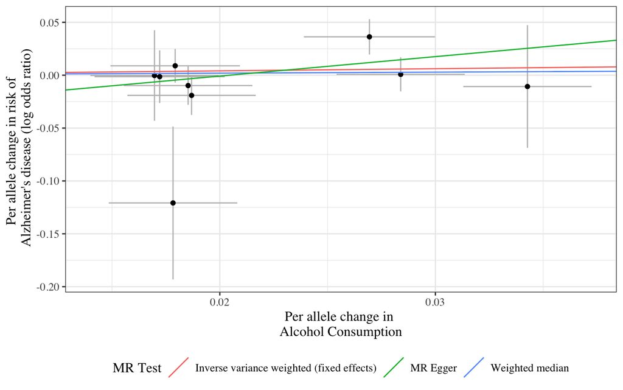

Fig. 1: Scatterplot of SNP effects for the association of Trait and LOAD

Figure 2 and Table 1 shows the SNP-specific effects and overall IVW, weighted median and Egger regression causal estimates of genetically predicted Alcohol Consumption on risk of LOAD.

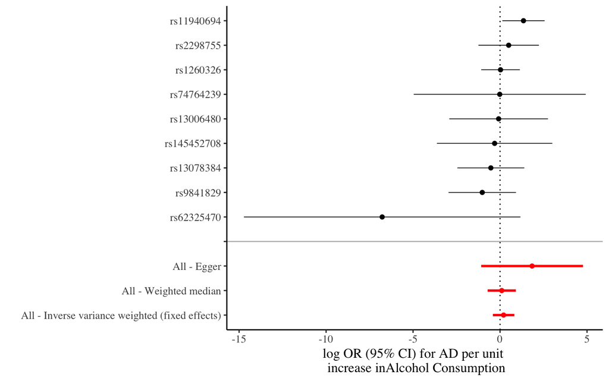

Fig. 2: Forrest plot of Wald ratios and 95% CIs for SNP-specific and overall IVW, Weighted median and Egger associations

**Table 1:** MR estimates for Alcohol Consumption and LOAD

|  | SNP | b | se | p |
| --- | --- | --- | --- | --- |
| 1 | rs11940694 | 1.34743875 | 0.6198961 | 0.02973123 |
| 2 | rs1260326 | 0.02817894 | 0.5671011 | 0.96036987 |
| 3 | rs13006480 | -0.08134805 | 1.4468332 | 0.95516265 |
| 4 | rs13078384 | -0.52887210 | 0.9821910 | 0.59025845 |
| 5 | rs145452708 | -0.31222644 | 1.6924424 | 0.85363475 |
| 6 | rs2298755 | 0.49637479 | 0.8867819 | 0.57565105 |
| 7 | rs62325470 | -6.77509815 | 4.0549635 | 0.09475802 |
| 8 | rs74764239 | -0.01767826 | 2.5220978 | 0.99440740 |
| 9 | rs9841829 | -1.02193686 | 0.9898341 | 0.30186959 |
| 10 | All - Inverse variance weighted (fixed effects) | 0.20538092 | 0.3148848 | 0.51424535 |

[output cut: 2 more lines]

Figure 3 shows a funnel plot to detect pleiotropy and Table 2 show the results of Cochrans Q heterogeneity test to assess for the presence of pleiotropy.

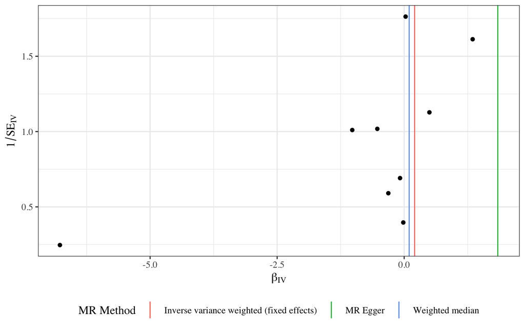

Fig. 3: Funnel plot of the Trait – LOAD causal estimates against their precession

**Table 2:** Heterogenity tests for Alcohol Consumption and LOAD

| exposure | outcome | method | Q | Q_df | Q_pval |
| --- | --- | --- | --- | --- | --- |
| alcc | LOAD | MR Egger | 7.456880 | 7 | 0.3829066 |
| alcc | LOAD | Inverse variance weighted | 8.799862 | 8 | 0.3594598 |

**Table 3:** Test for directional pleitropy for Alcohol Consumption and LOAD

| id.exposure | id.outcome | outcome | exposure | egger_intercept | se | pval |
| --- | --- | --- | --- | --- | --- | --- |
| wd4DZm | EkiKyh | LOAD | alcc | -0.03766433 | 0.03354475 | 0.2985483 |

### Alcohol Consumption ~ AAOS

Figure 4 illustrates the SNP-specific associations with Alcohol Consumption versus the association between each SNP and AAOS.

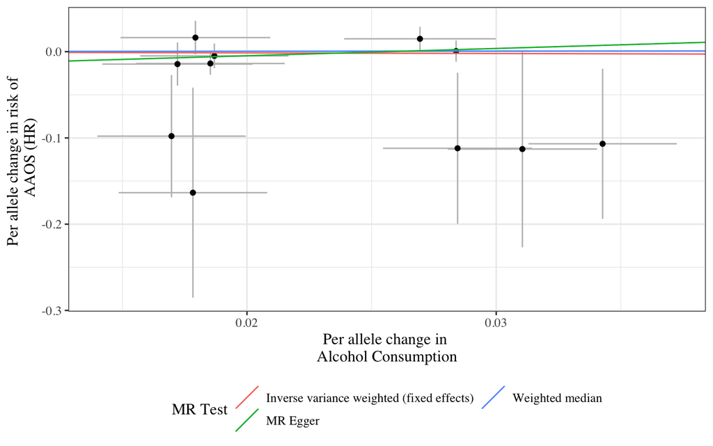

Fig. 4: Scatterplot of SNP effects for the association of Trait and AAOS

Figure 5 and Table 4 shows the SNP-specific effects and overall IVW, weighted median and Egger regression causal estimates of genetically predicted Alcohol Consumption on AAOS.

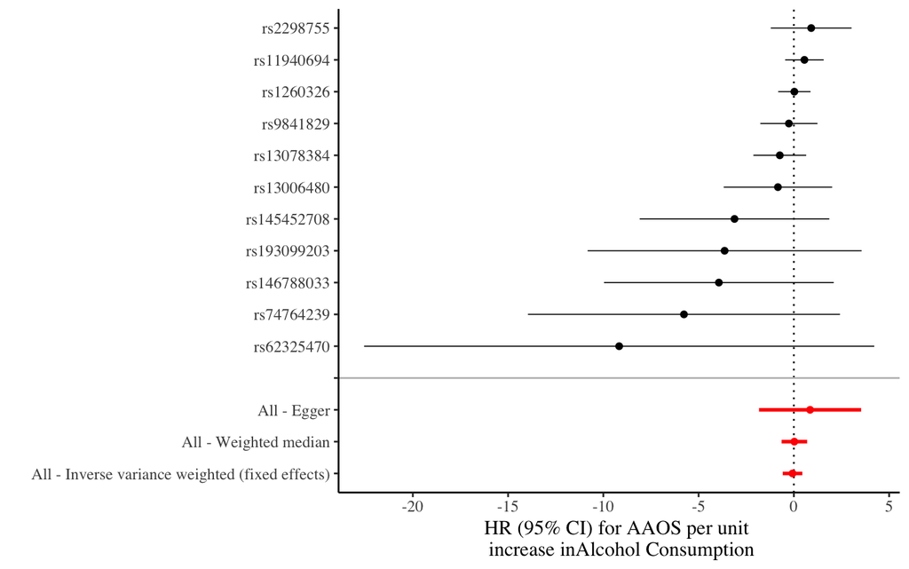

Fig. 5: Forrest plot of Wald ratios and 95% CIs for SNP-specific and overall IVW, Weighted median and Egger associations

**Table 4:** MR estimates for Alcohol Consumption and AAOS

|  | SNP | b | se | p |
| --- | --- | --- | --- | --- |
| 1 | rs11940694 | 0.55308092 | 0.5159614 | 0.2837459 |
| 2 | rs1260326 | 0.02465657 | 0.4332511 | 0.9546164 |
| 3 | rs13006480 | -0.83672284 | 1.4526438 | 0.5646152 |
| 4 | rs13078384 | -0.73934161 | 0.7069617 | 0.2956527 |
| 5 | rs145452708 | -3.11642836 | 2.5386636 | 0.2196023 |
| 6 | rs146788033 | -3.93673111 | 3.0755712 | 0.2005451 |
| 7 | rs193099203 | -3.63607085 | 3.6682770 | 0.3215780 |
| 8 | rs2298755 | 0.90909091 | 1.0819855 | 0.4007928 |
| 9 | rs62325470 | -9.16993831 | 6.8311834 | 0.1794778 |
| 10 | rs74764239 | -5.76900412 | 4.1779611 | 0.1673349 |

[output cut: 4 more lines]

Figure 6 shows a funnel plot to detect pleiotropy and Table 5 show the results of Cochrans Q heterogeneity test to assess for the presence of pleiotropy.

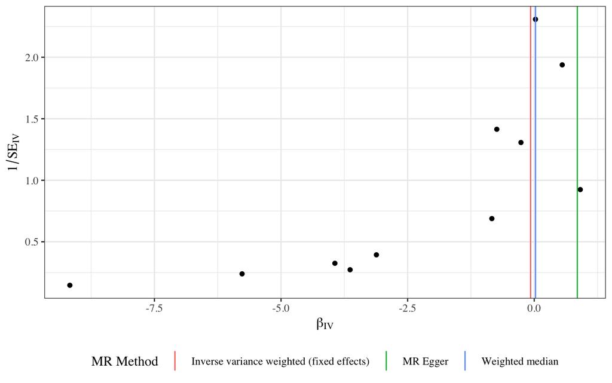

Fig. 6: Funnel plot of the traitohol Conumption – AAOS causal estimates against their precession

**Table 5:** Heterogenity tests for Alcohol Consumption and AAOS

| exposure | outcome | method | Q | Q_df | Q_pval |
| --- | --- | --- | --- | --- | --- |
| alcc | AAOS | MR Egger | 10.60379 | 9 | 0.3038473 |
| alcc | AAOS | Inverse variance weighted | 11.16390 | 10 | 0.3448921 |

**Table 6:** Test for directional pleitropy for Alcohol Consumption and AAOS

| id.exposure | id.outcome | outcome | exposure | egger_intercept | se | pval |
| --- | --- | --- | --- | --- | --- | --- |
| wd4DZm | SPhxvf | AAOS | alcc | -0.02172162 | 0.03150389 | 0.5079004 |

### Alcohol Consumption ~ AB42

Figure 1 illustrates the SNP-specific associations with Alcohol Consumption versus the association between each SNP and AB42.

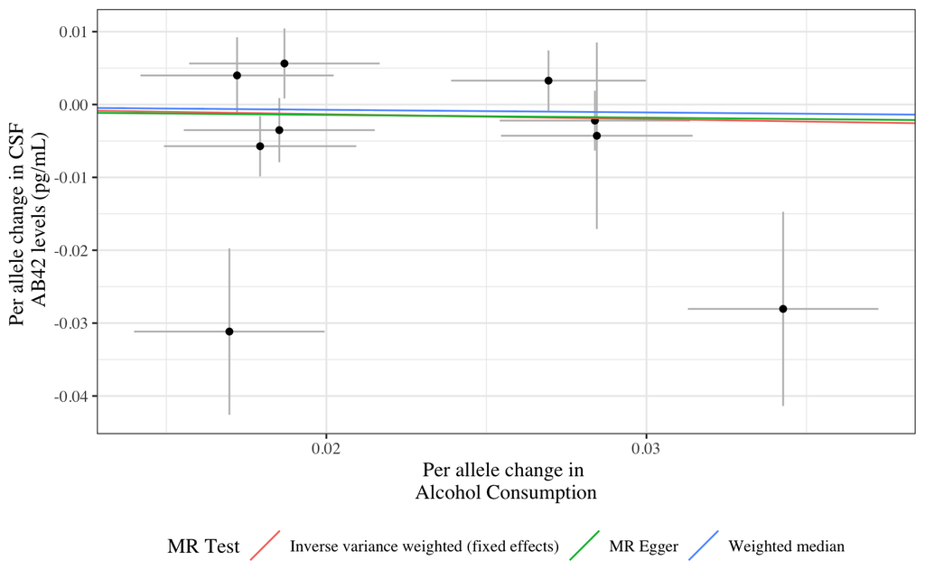

Fig. 1: Scatterplot of SNP effects for the association of trait and AB42

Figure 2 and Table 7 shows the SNP-specific effects and overall IVW, weighted median and Egger regression causal estimates of genetically predicted Alcohol Consumption CSF AB42 levels.

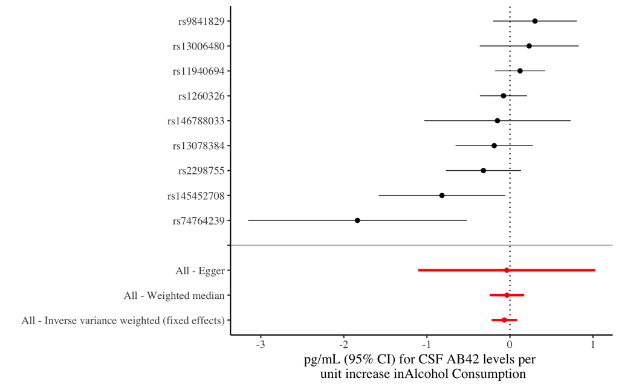

Fig. 2: Forrest plot of Wald ratios and 95% CIs for SNP-specific and overall IVW, Weighted median and Egger associations

**Table 7:** MR estimates for Alcohol Consumption and AB42

|  | SNP | b | se | p |
| --- | --- | --- | --- | --- |
| 1 | rs11940694 | 0.12156644 | 0.15386043 | 0.429464369 |
| 2 | rs1260326 | -0.07791476 | 0.14476928 | 0.590439316 |
| 3 | rs13006480 | 0.23178385 | 0.30429983 | 0.446241686 |
| 4 | rs13078384 | -0.18974636 | 0.23761468 | 0.424553452 |
| 5 | rs145452708 | -0.81850015 | 0.38896994 | 0.035354372 |
| 6 | rs146788033 | -0.15068541 | 0.44991213 | 0.737684020 |
| 7 | rs2298755 | -0.31929727 | 0.23100948 | 0.166915666 |
| 8 | rs74764239 | -1.83618150 | 0.67295227 | 0.006361414 |
| 9 | rs9841829 | 0.30112360 | 0.25735688 | 0.241975870 |
| 10 | All - Inverse variance weighted (fixed effects) | -0.06675594 | 0.07760057 | 0.389650937 |

[output cut: 2 more lines]

Figure 3 shows a funnel plot to detect pleiotropy and Table 8 show the results of Cochrans Q heterogeneity test to assess for the presence of pleiotropy.

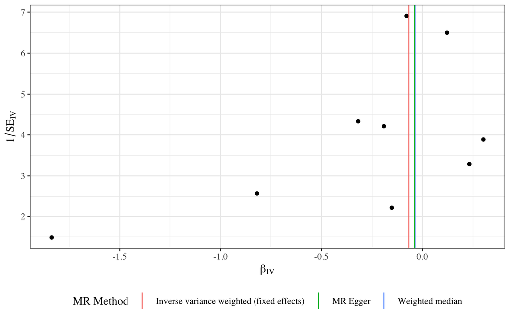

Fig. 3: Funnel plot of the trait – AB42 causal estimates against their precession

**Table 8:** Heterogenity tests for Alcohol Consumption and AB42

| exposure | outcome | method | Q | Q_df | Q_pval |
| --- | --- | --- | --- | --- | --- |
| alcc | ab42 | MR Egger | 16.64971 | 7 | 0.01980005 |
| alcc | ab42 | Inverse variance weighted | 16.65635 | 8 | 0.03389323 |

**Table 9:** Test for directional pleitropy for Alcohol Consumption and AB42

| id.exposure | id.outcome | outcome | exposure | egger_intercept | se | pval |
| --- | --- | --- | --- | --- | --- | --- |
| wd4DZm | MrG8Tt | ab42 | alcc | -0.0006485526 | 0.01227713 | 0.9593464 |

### Alcohol Consumption ~ Ptau

Figure 1 illustrates the SNP-specific associations with Alcohol Consumption versus the association between each SNP and risk of Ptau.

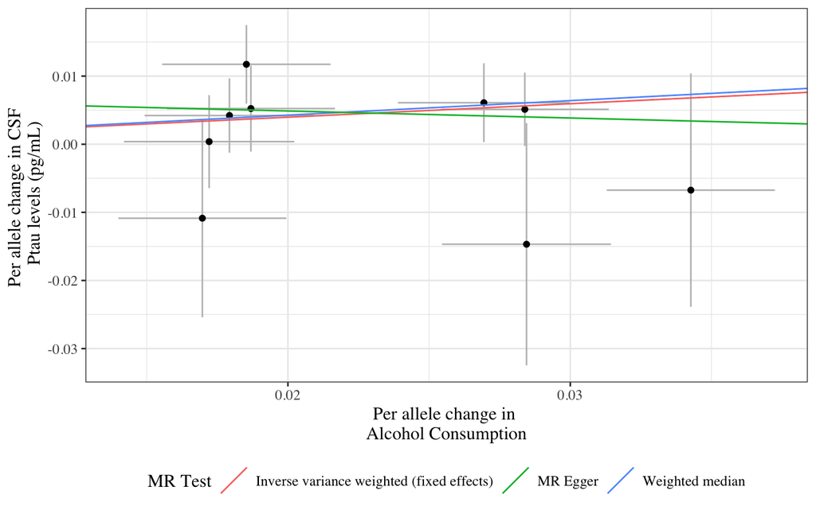

Fig. 1: Scatterplot of SNP effects for the association of trait and Ptau

Figure 2 and Table 9 shows the SNP-specific effects and overall IVW, weighted median and Egger regression causal estimates of genetically predicted Alcohol Consumption on risk of Ptau.

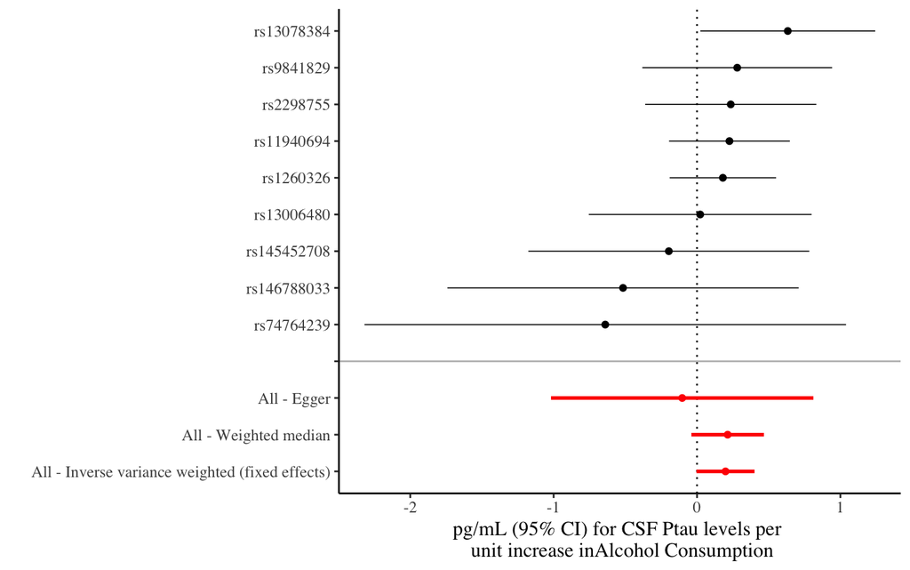

Fig. 2: Forrest plot of Wald ratios and 95% CIs for SNP-specific and overall IVW, Weighted median and Egger associations

**Table 9:** MR estimates for Alcohol Consumption and Ptau

|  | SNP | b | se | p |
| --- | --- | --- | --- | --- |
| 1 | rs11940694 | 0.22616927 | 0.2149592 | 0.29273079 |
| 2 | rs1260326 | 0.18038042 | 0.1893977 | 0.34089933 |
| 3 | rs13006480 | 0.02220221 | 0.3964555 | 0.95534041 |
| 4 | rs13078384 | 0.63302752 | 0.3111711 | 0.04191740 |
| 5 | rs145452708 | -0.19664430 | 0.4998541 | 0.69402157 |
| 6 | rs146788033 | -0.51599297 | 0.6249561 | 0.40900448 |
| 7 | rs2298755 | 0.23519241 | 0.3044618 | 0.43982675 |
| 8 | rs74764239 | -0.63995286 | 0.8568061 | 0.45512085 |
| 9 | rs9841829 | 0.28041734 | 0.3376137 | 0.40620734 |
| 10 | All - Inverse variance weighted (fixed effects) | 0.19872633 | 0.1033100 | 0.05440578 |

[output cut: 2 more lines]

Figure 3 shows a funnel plot to detect pleiotropy and Table 10 show the results of Cochrans Q heterogeneity test to assess for the presence of pleiotropy.

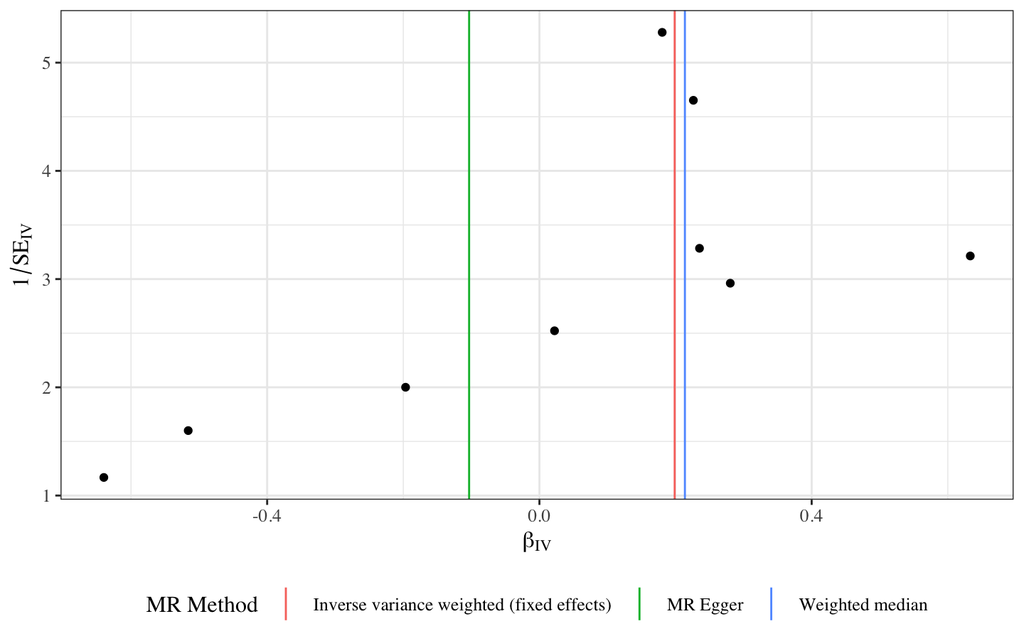

Fig. 3: Funnel plot of the trait – Ptau causal estimates against their precession

**Table 10:** Heterogenity tests for Alcohol Consumption and Ptau

| exposure | outcome | method | Q | Q_df | Q_pval |
| --- | --- | --- | --- | --- | --- |
| alcc | ptau | MR Egger | 4.696408 | 7 | 0.6969554 |
| alcc | ptau | Inverse variance weighted | 5.136467 | 8 | 0.7428958 |

**Table 11:** Test for directional pleitropy for Alcohol Consumption and Ptau

| id.exposure | id.outcome | outcome | exposure | egger_intercept | se | pval |
| --- | --- | --- | --- | --- | --- | --- |
| wd4DZm | CV7ZR8 | ptau | alcc | 0.006951985 | 0.01047981 | 0.5283278 |

### Alcohol Consumption ~ Tau

Figure 1 illustrates the SNP-specific associations with Alcohol Consumption versus the association between each SNP and CSF Tau levels.

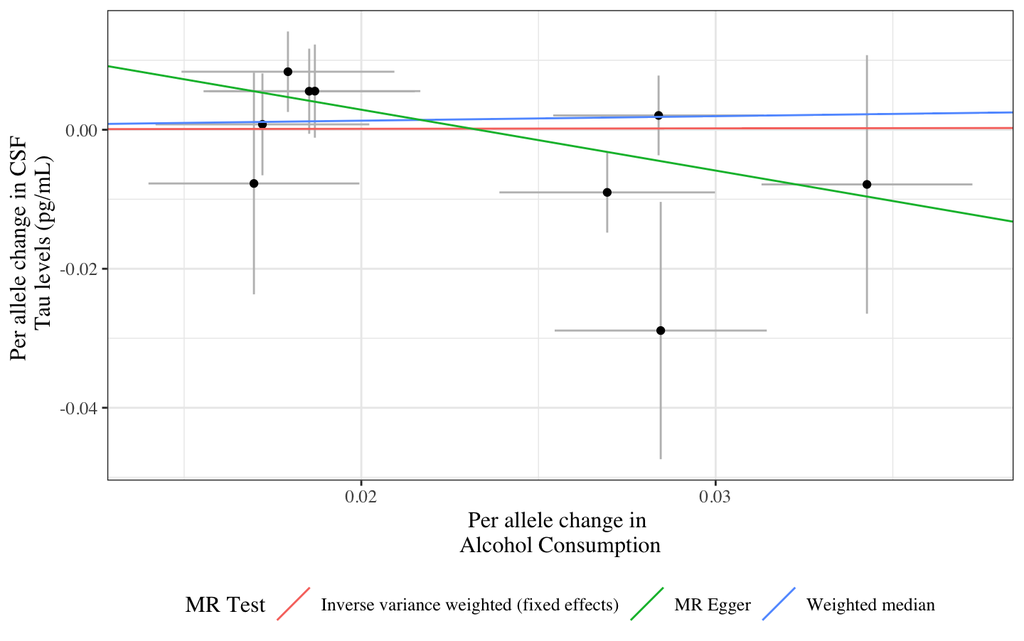

Fig. 1: Scatterplot of SNP effects for the association of trait and Tau

Figure 2 and Table 12 shows the SNP-specific effects and overall IVW, weighted median and Egger regression causal estimates of genetically predicted Alcohol Consumption on risk of Tau.

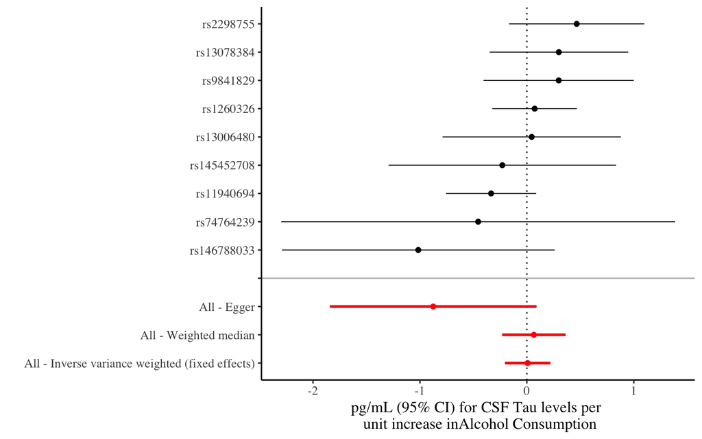

Fig. 2: Forrest plot of Wald ratios and 95% CIs for SNP-specific and overall IVW, Weighted median and Egger associations

**Table 12:** MR estimates for Alcohol Consumption and Tau

|  | SNP | b | se | p |
| --- | --- | --- | --- | --- |
| 1 | rs11940694 | -0.334521158 | 0.2149592 | 0.1196587 |
| 2 | rs1260326 | 0.072595985 | 0.2020782 | 0.7194103 |
| 3 | rs13006480 | 0.045037769 | 0.4256246 | 0.9157286 |
| 4 | rs13078384 | 0.299082569 | 0.3304911 | 0.3654844 |
| 5 | rs145452708 | -0.229530201 | 0.5427488 | 0.6723659 |
| 6 | rs146788033 | -1.015465729 | 0.6506151 | 0.1185761 |
| 7 | rs2298755 | 0.465699944 | 0.3228667 | 0.1491922 |
| 8 | rs74764239 | -0.455450796 | 0.9398939 | 0.6279766 |
| 9 | rs9841829 | 0.297431782 | 0.3585340 | 0.4067776 |
| 10 | All - Inverse variance weighted (fixed effects) | 0.007201849 | 0.1084226 | 0.9470404 |

[output cut: 2 more lines]

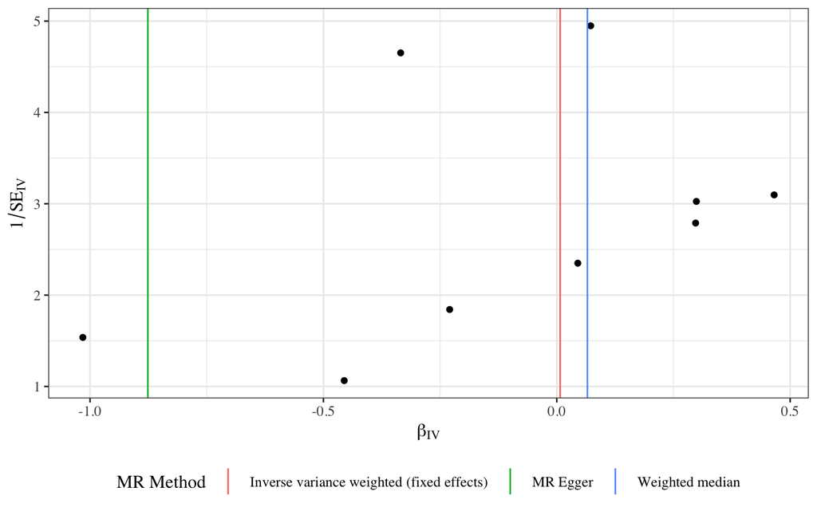

Fig. 3: Funnel plot of the trait – Tau causal estimates against their precession

**Table 14:** Heterogenity tests for Alcohol Consumption and Tau

| exposure | outcome | method | Q | Q_df | Q_pval |
| --- | --- | --- | --- | --- | --- |
| alcc | tau | MR Egger | 5.623956 | 7 | 0.5842776 |
| alcc | tau | Inverse variance weighted | 8.994966 | 8 | 0.3427208 |

**Table 15:** Test for directional pleitropy for Alcohol Consumption and Tau

| id.exposure | id.outcome | outcome | exposure | egger_intercept | se | pval |
| --- | --- | --- | --- | --- | --- | --- |
| wd4DZm | TTu8qM | tau | alcc | 0.02041521 | 0.0111192 | 0.1089774 |

## MR analysis results

| exposure | outcome | method | nsnp | b | se | pval | Signif |
| --- | --- | --- | --- | --- | --- | --- | --- |
| alcc | LOAD | IVW | 9 | 0.205380923 | 0.31488475 | 0.51424535 |  |
| alcc | LOAD | Weighted median | 9 | 0.098040801 | 0.42487578 | 0.81750772 |  |
| alcc | LOAD | MR Egger | 9 | 1.841900412 | 1.49331785 | 0.25722279 |  |
| alcc | AAOS | IVW | 11 | -0.071218887 | 0.26229770 | 0.78599166 |  |
| alcc | AAOS | Weighted median | 11 | 0.025610952 | 0.32681536 | 0.93753755 |  |
| alcc | AAOS | MR Egger | 11 | 0.850637221 | 1.36698913 | 0.54920229 |  |
| alcc | ab42 | IVW | 9 | -0.066755935 | 0.07760057 | 0.38965094 |  |
| alcc | ab42 | Weighted median | 9 | -0.036054823 | 0.10514827 | 0.73167741 |  |
| alcc | ab42 | MR Egger | 9 | -0.038708419 | 0.54426212 | 0.94529082 |  |
| alcc | ptau | IVW | 9 | 0.198726329 | 0.10331003 | 0.05440578 | . |

[output cut: 5 more lines]